# Introduction to ClustGeo

2018-11-11

The R package `ClustGeo` implements a Ward-like hierarchical clustering algorithm including spatial/geographical constraints. Two dissimilarity matrices `D0` and `D1` are inputted, along with a mixing parameter `alpha` in $[0,1]$. The dissimilarities can be non-Euclidean and the weights of the observations can be non-uniform. The first matrix gives the dissimilarities in the “feature space”" and the second matrix gives the dissimilarities in the “constraint space”. The criterion minimized at each stage is a convex combination of the homogeneity criterion calculated with `D0` and the homogeneity criterion calculated with `D1`. The idea is to determine a value of `alpha` which increases the spatial contiguity without deteriorating too much the quality of the solution based on the variables of interest i.e. those of the feature space. This procedure is illustrated on the `estuary` dataset available in the package.

## The `estuary` dataset

The dataset `estuary` refers to $n=303$ French municipalities of Gironde estuary (a south-ouest French region). This dataset contains:

- a data frame `dat` with the description of the 303 municipalities on 4 socio-economic variables,
- a matrix `D.geo` with the distances between the town halls of the 303 municipalities,
- an object `map` of class `SpatialPolygonsDataFrame` with the map of the municipalities.

```r
library(ClustGeo)
data(estuary)
dat <- estuary$dat
head(dat)
```

```
##       employ.rate.city graduate.rate housing.appart agri.land
## 17015            28.08         17.68           5.15  90.04438
## 17021            30.42         13.13           4.93  58.51182
## 17030            25.42         16.28           0.00  95.18404
## 17034            35.08          9.06           0.00  91.01975
## 17050            28.23         17.13           2.51  61.71171
## 17052            22.02         12.66           3.22  61.90798
```

```r
D.geo <- estuary$D.geo
map <- estuary$map
```

The object `map` is an object of class `SpatialPolygonsDataFrame` (of the package `sp`) and the method `plot` can be used to visualize the municipalities on the map.

```r
# description of 5 municipalities in the map
head(map@data[,4:8])
```

```
##        NOM_COMM X_CHF_LIEU Y_CHF_LIEU X_CENTROID Y_CENTROID
## 17015     ARCES       3989      65021       3979      65030
## 17021    ARVERT       3791      65240       3795      65247
## 17030  BALANZAC       4018      65230       4012      65237
## 17034    BARZAN       3991      64991       3982      64997
## 17050      BOIS       4189      64940       4176      64934
## 17052 BOISREDON       4227      64745       4224      64749
```

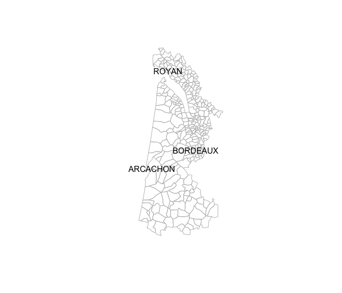

```r
# plot of the municipalities
library(sp)
?"SpatialPolygonsDataFrame-class"
sp::plot(map, border="grey") # plot method
sel <- map$NOM_COMM%in% c("BORDEAUX", "ARCACHON", "ROYAN") # label of 3 municipalities
text(sp::coordinates(map)[sel,],
     labels = map$NOM_COMM[sel])
```

```r
# we check that the municipalities in map are the same than those in X
identical(as.vector(map$INSEE_COM),rownames(dat))
```

```
## [1] TRUE
```

## Hierarchical clustering with soft contiguity constraint.

The function `hclustgeo` implements a Ward-like hierarchical clustering algorithm with soft contiguity constraint. The main arguments of the function are:

- a matrix `D0` with the dissimilarities in the “feature space” (here socio-economic variables for instance).
- a matrix `D1` with the dissimilarities in the “constraint” space (here a matrix of geographical dissimilarities).
- a mixing parameter `alpha` between 0 an 1. The mixing parameter sets the importance of the constraint in the clustering procedure.
- a scaling parameter `scale` with a logical value. If `TRUE` the dissimilarity matrices `D0` and `D1` are scaled between 0 and 1 (that is divided by their maximum value).

The function `choicealpha` implements a procedure to help the user in the choice of a suitable value of the mixing parameter `alpha`.

Both `hclustgeo` and `choicealpha` can be combined to find a partition of the $n=303$ French municipalities including geographical contiguity constraint. The two steps of the procedure are :

1. Find partition in $K$ clusters of the 303 municipalities using the dissimilarity matrix `D0`. The clusters of this partition are homogeneous on the socio-economic variables and no contiguity constraint is used.
2. Choose a mixing parameter `alpha` in order to increases the geographical cohesion of the clusters (using the dissimilarity matrix `D1`) without deteriorating too much the homogeneity on the socio-economic variables.

### Find a partition with no constraint

Ward hierarchical clustering of the 303 municipalities is performed using the dissimilarity matrix `D0` (calculated with the socio-economic variables). The partition in $K=5$ clusters is chosen from the Ward dendrogram.

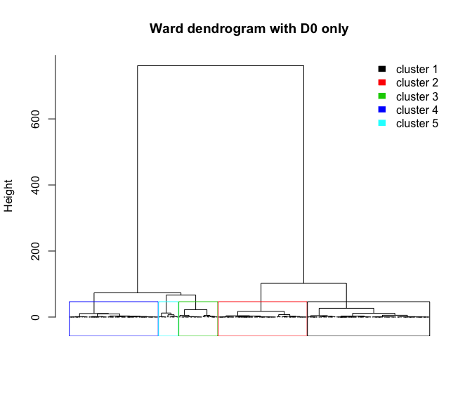

```r
D0 <- dist(dat) # the socio-economic distances
tree <- hclustgeo(D0)
plot(tree,hang = -1, label = FALSE,
     xlab = "", sub = "",
     main = "Ward dendrogram with D0 only")

rect.hclust(tree ,k = 5, border = c(4,5,3,2,1))
legend("topright", legend = paste("cluster",1:5),
       fill=1:5,bty= "n", border = "white")
```

This partition is plotted on the `estuay` map.

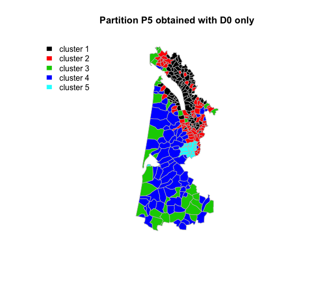

```r
# cut the dendrogram to get the partition in 5 clusters
P5 <- cutree(tree,5)
city_label <- as.vector(map$"NOM_COMM")
names(P5) <- city_label

plot(map, border = "grey", col = P5,
         main = "Partition P5 obtained with D0 only")
legend("topleft", legend = paste("cluster",1:5),
       fill = 1:5, bty = "n", border = "white")
```

```r
# list of the municipalities in cluster 5
city_label[which(P5==5)]
```

```
##  [1] "ARCACHON"          "BASSENS"           "BEGLES"
##  [4] "BORDEAUX"          "LE BOUSCAT"        "BRUGES"
##  [7] "CARBON-BLANC"      "CENON"             "EYSINES"
## [10] "FLOIRAC"           "GRADIGNAN"         "LE HAILLAN"
## [13] "LORMONT"           "MERIGNAC"          "PESSAC"
## [16] "TALENCE"           "VILLENAVE-D'ORNON"
```

### Change the partition to take geographical constraint into account

In order to get more spatially compact clusters, the matrix `D1` of the distances between the town halls of the municipalities, is included in the clustering process along with the mixing parameter `alpha` used to set the importance of `D0` and `D1`.

```r
D1 <- as.dist(D.geo) # the geographic distances between the municipalities
```

The mixing parameter `alpha` is chosen in such a way that the geographical cohesion of the clusters is improved without deteriorating too much the socio-economic cohesion.

#### Choice of the mixing parameter `alpha`

The mixing parameter `alpha` in $[0,1]$ sets the importance of `D0` and `D1` in the clustering process. When `alpha`=0 the geographical dissimilarities are not taken into account and when `alpha`=1 it is the socio-economic distances which are not taken into account and the clusters are obtained with the geographical distances only.

The idea is then to calculate separately the socio-economic homogeneity (denoted `Q0`) and the geographic homogneity (denoted `Q1`) of the partitions obtained for a range of different values of `alpha` and a given number of clusters $K$. The homogeneity `Q0` (resp. `Q1`) is the proportion of explained inertia calculated with `D0` (resp. `D1`).

```r
range.alpha <- seq(0,1,0.1)
K <- 5
cr <- choicealpha(D0, D1, range.alpha,
  K, graph = FALSE)
cr$Q # proportion of explained inertia
```

```
##                  Q0        Q1
## alpha=0   0.8134914 0.4033353
## alpha=0.1 0.8123718 0.3586957
## alpha=0.2 0.7558058 0.7206956
## alpha=0.3 0.7603870 0.6802037
## alpha=0.4 0.7062677 0.7860465
## alpha=0.5 0.6588582 0.8431391
## alpha=0.6 0.6726921 0.8377236
## alpha=0.7 0.6729165 0.8371600
## alpha=0.8 0.6100119 0.8514754
## alpha=0.9 0.5938617 0.8572188
## alpha=1   0.5016793 0.8726302
```

The plot of the curves of `Q0` and `Q1` is a tool to choose a value of `alpha` that is a compromise between the lost in socio-economic homogeneity and the gain in geographic cohesion.

```r
?plot.choicealpha
```

```
## Rendering development documentation for 'plot.choicealpha'
```

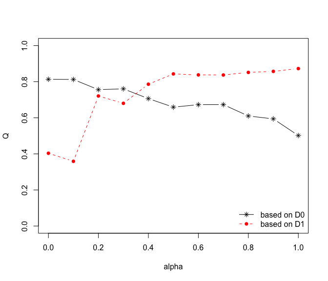

```r
plot(cr)
```

We see that the proportion of explained inertia calculated with `D0` (the socio-economic distances) is equal to 0.81 when `alpha`=0 and decreases when `alpha` inceases (black line). On the contrary the proportion of explained inertia calculated with `D1` (the geographical distances) is equal to 0.87 when `alpha`=1 and decreases when `alpha` decreases (red line).

#### Modified partition obtained with `alpha`=0.2

The dendrogram obtained with the function `hclustgeo` and `alpha`=0.2 of is cut to get the new partition in 5 clusters.

```r
tree <- hclustgeo(D0,D1,alpha=0.2)
P5bis <- cutree(tree,5)
```

The modified partition `P5bis` is visualized on the map.

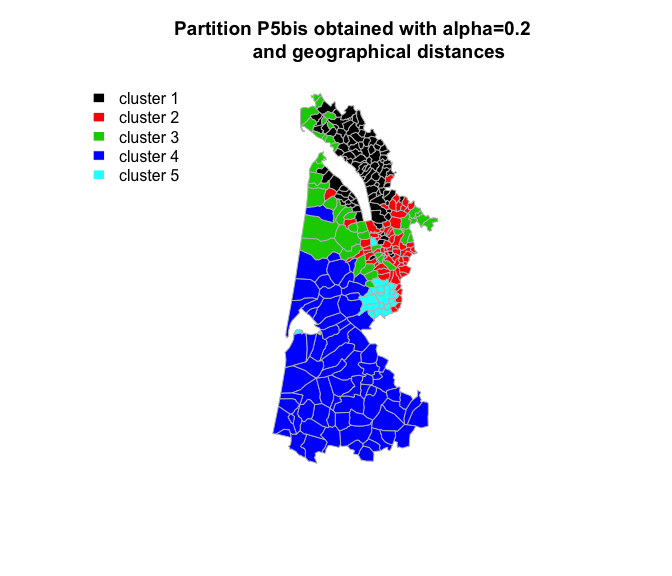

```r
sp::plot(map, border = "grey", col = P5bis,
         main = "Partition P5bis obtained with alpha=0.2
         and geographical distances")
legend("topleft", legend=paste("cluster",1:5),
       fill=1:5, bty="n",border="white")
```

We see that the geographical cohesion of the partition `P5bis` is increased compared to partition `P5`.

### Change the partition to take neighborhood constraint into account

Here a different matrix of dissimilarities `D1` is considered to take the neighborhood between the municipalities into account rather than the geographical distance. Two municipalities with contiguous boundaries (sharing one or more boundary point) are considered as neighbours. The adjacency matrix `A` is the binary matrix of the neighbourhoods between the municipalities.

```r
library(spdep)
?poly2nb
list.nb <- poly2nb(map, row.names = rownames(dat)) #list of neighbours of each city
?nb2mat
A <- nb2mat(list.nb,style="B")
diag(A) <- 1
colnames(A) <- rownames(A) <- city_label
A[1:5,1:5]
```

```
##          ARCES ARVERT BALANZAC BARZAN BOIS
## ARCES        1      0        0      1    0
## ARVERT       0      1        0      0    0
## BALANZAC     0      0        1      0    0
## BARZAN       1      0        0      1    0
## BOIS         0      0        0      0    1
```

The dissimilarity matrix `D1` is then 1 minus `A`.

```r
D1 <- as.dist(1-A)
```

#### Choice of the mixing parameter `alpha`

The procedure for the choice of `alpha` is repeated here with the new matrix `D1`.

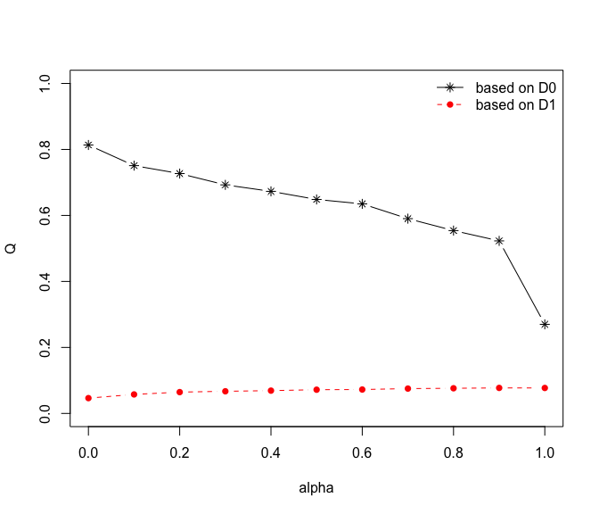

```r
range.alpha <- seq(0,1,0.1)
K <- 5
cr <- choicealpha(D0, D1, range.alpha,
                  K, graph=FALSE)
plot(cr)
```

The explained inertia calculated here with `D1` (red curve) is much smaller than the explained inertia calculated with `D0` (black curve). To overcome this problem, the normalized proportion of explained inertia (`Qnorm`) is plotted.

```r
cr$Qnorm # normalized proportion of explained inertia
```

```
##              Q0norm    Q1norm
## alpha=0   1.0000000 0.6009518
## alpha=0.1 0.9231102 0.7462157
## alpha=0.2 0.8935510 0.8370184
## alpha=0.3 0.8514257 0.8698485
## alpha=0.4 0.8272982 0.8952084
## alpha=0.5 0.7971311 0.9320703
## alpha=0.6 0.7806226 0.9386452
## alpha=0.7 0.7255676 0.9756566
## alpha=0.8 0.6811587 0.9880916
## alpha=0.9 0.6427471 1.0018473
## alpha=1   0.3318727 1.0000000
```

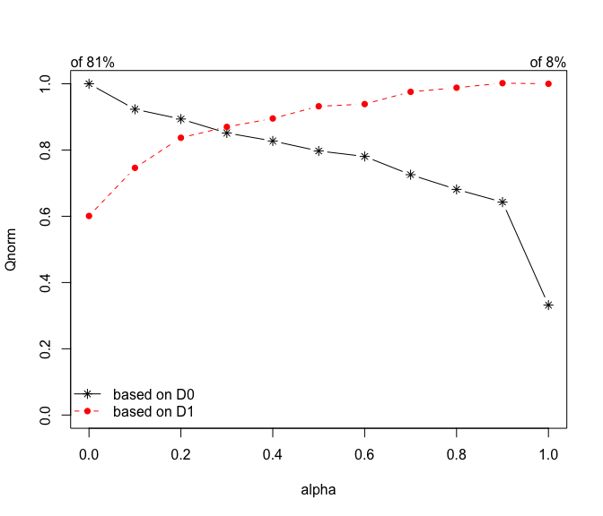

```r
plot(cr, norm = TRUE)
```

With `D0` the curve starts from 100% and decreases as `alpha` increases from 0 to 1. With `D1` the curve starts from 100% (on the right) and decreases as `alpha` decreases from 1 to 0. This plot suggests to choose `alpha`=0.2

#### Modified partition obtained with `alpha`=0.2

The dendrogram obtained with the function `hclustgeo` and `alpha`=0.2 of is cut to get a new partition in 5 clusters.

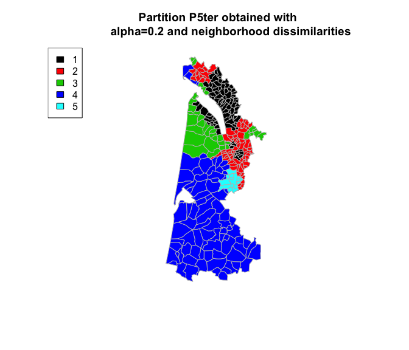

```r
tree <- hclustgeo(D0, D1, alpha  =0.2)
P5ter <- cutree(tree,5)
sp::plot(map, border="grey", col=P5ter,
         main=" Partition P5ter obtained with
         alpha=0.2 and neighborhood dissimilarities")
legend("topleft", legend=1:5, fill=1:5, col=P5ter)
```

This partition `P5ter` is spatially more compact than `P5bis`. This is not surprising since dissimilarities are build from the adjacency matrix which gives more importance local neighborhoods. However since the clustering process is based on soft contiguity constraints, municipalities that are not neighbors are allowed to be in the same clusters. This is the case for instance for `cluster 4` where some municipalities are located in the north of the estuary whereas most are located in the southern area (corresponding to forest areas).

## Reference

M. Chavent, V. Kuentz-Simonet, A. Labenne, J. Saracco. ClustGeo: an R package for hierarchical clustering with spatial constraints.Comput Stat (2018) 33: 1799-1822.